# R - Abalone - Regression Methods, Regularization, and PCA

Christoph Schauer

22 July 2018

## Introduction

This notebook is for practicing machine learning with different parametric regression and regularization methods – linear and polynomial regression, ridge regression, lasso, and stepwise model selection – with the caret and glmnet packages as well as preprocessing data with PCA.

The data used is the Abalone data set from the [UCI Machine Learning Repository](http://archive.ics.uci.edu/ml/datasets/Abalone). This data set contains 4177 observations of 9 physical attributes – sex, length, diameter, height, whole weight, shucked weight, viscera weight, shell weight, and rings – of abalone snails. The number of rings in the shell plus 1.5 gives the age of a snail in years. The goal is to predict the age from all other attributes. From the description of the data set:

*The age of abalone is determined by cutting the shell through the cone, staining it, and counting the number of rings through a microscope – a boring and time-consuming task. Other measurements, which are easier to obtain, are used to predict the age.*

As it turned out, this dataset is actually a poor choice for showcasing regularization methods, as the structure of the data is such that these models don’t offer any real advantage in terms of prediction accuracy. And due to all features being highly correlated, two principal components already capture more than 95% of the variance. It’s still fine practing coding though.

## Setup

#### Load required packages

```r
library(tidyverse)
library(gridExtra)
library(caret)
library(glmnet)
library(leaps)
library(knitr)
```

#### Load and prepare data

```r
abalone = read_csv("abalone_data.txt", col_names = FALSE)
colnames(abalone) = c("sex", "length", "diameter", "height", "weight_whole",
                      "weight_shucked", "weight_viscera", "weight_shell", "rings")
abalone$sex = as.factor(abalone$sex)
```

#### Partition data into training and test set

```r
set.seed(123)
in_train = createDataPartition(y = abalone$rings, p = 0.75, list = FALSE)
abalone_train = abalone[in_train,]
abalone_test = abalone[-in_train,]
nrow(abalone_train)
```

```
## [1] 3134
```

```r
nrow(abalone_test)
```

```
## [1] 1043
```

25% of the data is assigned to the test set.

## Exploratory analysis

#### Summary statistics

```r
abalone_train
```

```
## # A tibble: 3,134 x 9
##    sex   length diameter height weight_whole weight_shucked weight_viscera
##    <fct>  <dbl>    <dbl>  <dbl>        <dbl>          <dbl>          <dbl>
##  1 M      0.35     0.265  0.09         0.226         0.0995         0.0485
##  2 F      0.53     0.42   0.135        0.677         0.256          0.142
##  3 I      0.33     0.255  0.08         0.205         0.0895         0.0395
##  4 I      0.425    0.3    0.095        0.352         0.141          0.0775
##  5 F      0.53     0.415  0.15         0.778         0.237          0.142
##  6 M      0.475    0.37   0.125        0.509         0.216          0.112
##  7 M      0.43     0.35   0.11         0.406         0.168          0.081
##  8 M      0.49     0.38   0.135        0.542         0.218          0.095
##  9 F      0.535    0.405  0.145        0.684         0.272          0.171
## 10 F      0.47     0.355  0.1          0.476         0.168          0.0805
## # ... with 3,124 more rows, and 2 more variables: weight_shell <dbl>,
## #   rings <dbl>
```

```r
summary(abalone_train)
```

```
##  sex          length          diameter          height
##  F: 963   Min.   :0.0750   Min.   :0.0550   Min.   :0.0000
##  I:1008   1st Qu.:0.4500   1st Qu.:0.3450   1st Qu.:0.1150
##  M:1163   Median :0.5400   Median :0.4200   Median :0.1400
##           Mean   :0.5223   Mean   :0.4066   Mean   :0.1389
##           3rd Qu.:0.6150   3rd Qu.:0.4800   3rd Qu.:0.1650
##           Max.   :0.8150   Max.   :0.6500   Max.   :0.5150
##   weight_whole    weight_shucked   weight_viscera    weight_shell
##  Min.   :0.0020   Min.   :0.0010   Min.   :0.0005   Min.   :0.0015
##  1st Qu.:0.4415   1st Qu.:0.1850   1st Qu.:0.0930   1st Qu.:0.1283
##  Median :0.7913   Median :0.3322   Median :0.1695   Median :0.2298
##  Mean   :0.8227   Mean   :0.3568   Mean   :0.1795   Mean   :0.2369
##  3rd Qu.:1.1464   3rd Qu.:0.4984   3rd Qu.:0.2505   3rd Qu.:0.3250
##  Max.   :2.7795   Max.   :1.4880   Max.   :0.7600   Max.   :1.0050
##      rings
##  Min.   : 1.000
##  1st Qu.: 8.000
##  Median : 9.000
##  Mean   : 9.914
##  3rd Qu.:11.000
##  Max.   :29.000
```

#### Distribution of rings (i.e. age)

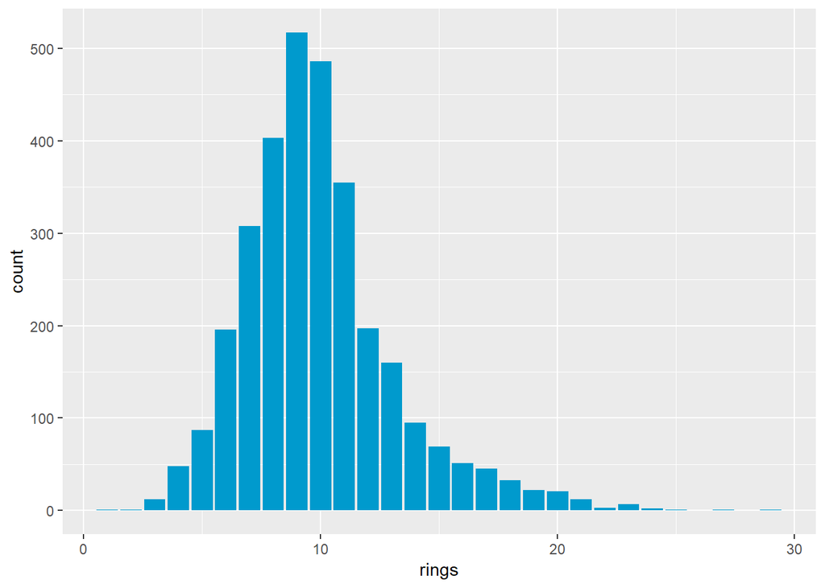

```r
ggplot(abalone_train) + geom_bar(aes(x = rings), fill = "deepskyblue3")
```

#### Scatterplots of selected predictors

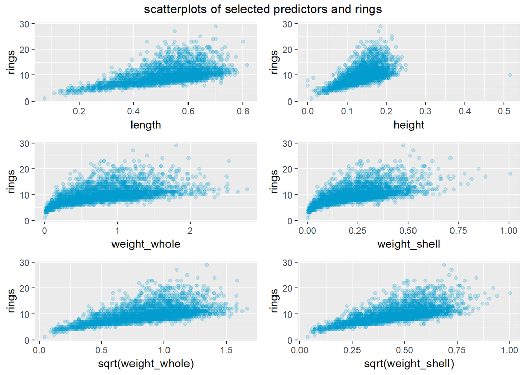

```r
grid.arrange(
     ggplot(abalone_train) + geom_point(aes(x = length, y = rings), color = "deepskyblue3", alpha = 0.2),
     ggplot(abalone_train) + geom_point(aes(x = height, y = rings), color = "deepskyblue3", alpha = 0.2),
     ggplot(abalone_train) + geom_point(aes(x = weight_whole, y = rings), color = "deepskyblue3", alpha = 0.2),
     ggplot(abalone_train) + geom_point(aes(x = weight_shell, y = rings), color = "deepskyblue3", alpha = 0.2),
     ggplot(abalone_train) + geom_point(aes(x = sqrt(weight_whole), y = rings), color = "deepskyblue3",
                                        alpha = 0.2),
     ggplot(abalone_train) + geom_point(aes(x = sqrt(weight_shell), y = rings), color = "deepskyblue3",
                                        alpha = 0.2),
     ncol = 2, top = "scatterplots of selected predictors and rings"
)
```

The relationship between rings and length, and height is pretty linear. After taking the square root of the weight variables, their relationship with rings looks relatively linear as well. Linear regression models are therefore good candidates for prediction.

I will estimate linear models with regular weight variables as well as their square roots to compare the accuracy of both models, but use only non-squared variables in all subsequent models for the sake of simplicity.

The variance of all predictors seems to increase with age, naturally, therefore heteroskedasticity could be an issue for estimating the statistical significance and such. This could be addressed e.g. by preprocessing the data with a Box-Cox transformation. I’ve already had to deal with heteroskedasticity in my econometrics classes many times, so I’ll ignore that here for now. It doesn’t matter for prediction accuracy anyway.

#### Correlation and covariance

```r
kable(cor(abalone_train[,2:8]), caption = "correlation table")
```

correlation table

|  | length | diameter | height | weight_whole | weight_shucked | weight_viscera | weight_shell |
| --- | --- | --- | --- | --- | --- | --- | --- |
| length | 1.0000000 | 0.9876898 | 0.8930925 | 0.9263648 | 0.8961603 | 0.9038949 | 0.9002521 |
| diameter | 0.9876898 | 1.0000000 | 0.8972942 | 0.9258713 | 0.8912030 | 0.9003254 | 0.9069831 |
| height | 0.8930925 | 0.8972942 | 1.0000000 | 0.8805931 | 0.8313893 | 0.8616470 | 0.8792097 |
| weight_whole | 0.9263648 | 0.9258713 | 0.8805931 | 1.0000000 | 0.9696024 | 0.9683524 | 0.9546472 |
| weight_shucked | 0.8961603 | 0.8912030 | 0.8313893 | 0.9696024 | 1.0000000 | 0.9310904 | 0.8802089 |
| weight_viscera | 0.9038949 | 0.9003254 | 0.8616470 | 0.9683524 | 0.9310904 | 1.0000000 | 0.9104702 |
| weight_shell | 0.9002521 | 0.9069831 | 0.8792097 | 0.9546472 | 0.8802089 | 0.9104702 | 1.0000000 |

```r
kable(cov(abalone_train[,2:8]), caption = "covariance table")
```

covariance table

|  | length | diameter | height | weight_whole | weight_shucked | weight_viscera | weight_shell |
| --- | --- | --- | --- | --- | --- | --- | --- |
| length | 0.0145413 | 0.0118795 | 0.0042083 | 0.0544242 | 0.0239217 | 0.0119120 | 0.0149987 |
| diameter | 0.0118795 | 0.0099484 | 0.0034972 | 0.0449921 | 0.0196770 | 0.0098139 | 0.0124987 |
| height | 0.0042083 | 0.0034972 | 0.0015270 | 0.0167648 | 0.0071916 | 0.0036797 | 0.0047467 |
| weight_whole | 0.0544242 | 0.0449921 | 0.0167648 | 0.2373654 | 0.1045700 | 0.0515594 | 0.0642600 |
| weight_shucked | 0.0239217 | 0.0196770 | 0.0071916 | 0.1045700 | 0.0490015 | 0.0225249 | 0.0269203 |
| weight_viscera | 0.0119120 | 0.0098139 | 0.0036797 | 0.0515594 | 0.0225249 | 0.0119435 | 0.0137474 |
| weight_shell | 0.0149987 | 0.0124987 | 0.0047467 | 0.0642600 | 0.0269203 | 0.0137474 | 0.0190888 |

All predictors are quite highly correlated. Excluding some of these predictors might therefore lead to only minimal loss in prediction accuracy. I will estimate some sparse models with lasso, stepwise model selection, and prinicipal component analysis.

## Linear and polynomial regression models - with caret

#### Linear regression

```r
lm1 = train(rings ~ ., data = abalone_train, method = "lm")
summary(lm1)
```

```
##
## Call:
## lm(formula = .outcome ~ ., data = dat)
##
## Residuals:
##     Min      1Q  Median      3Q     Max
## -8.4800 -1.2947 -0.3429  0.8717 13.8545
##
## Coefficients:
##                 Estimate Std. Error t value Pr(>|t|)
## (Intercept)      3.53623    0.33605  10.523  < 2e-16 ***
## sexI            -0.73844    0.11780  -6.269 4.14e-10 ***
## sexM             0.01106    0.09577   0.116  0.90803
## length          -0.76042    2.14429  -0.355  0.72289
## diameter         8.66142    2.63213   3.291  0.00101 **
## height          22.91556    2.44887   9.358  < 2e-16 ***
## weight_whole     9.71410    0.89275  10.881  < 2e-16 ***
## weight_shucked -20.09991    0.98304 -20.447  < 2e-16 ***
## weight_viscera -12.78417    1.56175  -8.186 3.90e-16 ***
## weight_shell     7.51086    1.34409   5.588 2.49e-08 ***
## ---
## Signif. codes:  0 '***' 0.001 '**' 0.01 '*' 0.05 '.' 0.1 ' ' 1
##
## Residual standard error: 2.183 on 3124 degrees of freedom
## Multiple R-squared:  0.5467, Adjusted R-squared:  0.5454
## F-statistic: 418.6 on 9 and 3124 DF,  p-value: < 2.2e-16
```

```r
rings_pred_lm1 = predict(lm1, newdata = abalone_test)
sqrt(mean((rings_pred_lm1 - abalone_test$rings)^2))
```

```
## [1] 2.295155
```

#### Residual analysis of the linear model

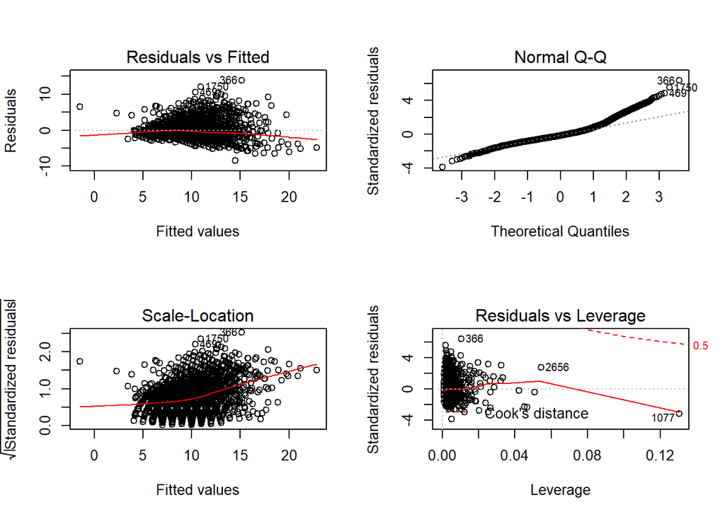

```r
par(mfrow = c(2,2))
plot(lm(rings ~ ., data = abalone_train))
```

#### Linear regression with square root of weight variables

```r
lm2 = train(rings ~ sex + length + diameter + height + sqrt(weight_whole) + sqrt(weight_shucked) +
                 sqrt(weight_viscera) + sqrt(weight_shell), data = abalone_train, method = "lm")
rings_pred_lm2 = predict(lm2, newdata = abalone_test)
sqrt(mean((rings_pred_lm2 - abalone_test$rings)^2)) # RMSE
```

```
## [1] 2.219239
```

```r
mean(abs(rings_pred_lm2 - abalone_test$rings)) # ME
```

```
## [1] 1.565481
```

This model is more accurate than the standard linear model. On average, this model errs by about 1.6 years when predicting the age of abalone.

#### Polynomial regression

```r
lm3 = train(rings ~ sex + poly(length, 3) + poly(diameter, 3) + poly(height, 3) +
                  poly(weight_whole, 3) + poly(weight_viscera, 3) + poly(weight_shell, 3) +
                  poly(diameter, 3), data = abalone_train, method = "lm")
rings_pred_lm3 = predict(lm3, newdata = abalone_test)
sqrt(mean((rings_pred_lm3 - abalone_test$rings)^2))
```

```
## [1] 2.7118
```

The model with polynomials is less accurate.

## Regularized regression - with caret

#### Ridge regression (elasticnet implementation)

```r
ridge1 = train(rings ~ ., data = abalone_train, method = "ridge", preProcess = c("center", "scale"))
ridge1
```

```
## Ridge Regression
##
## 3134 samples
##    8 predictor
##
## Pre-processing: centered (9), scaled (9)
## Resampling: Bootstrapped (25 reps)
## Summary of sample sizes: 3134, 3134, 3134, 3134, 3134, 3134, ...
## Resampling results across tuning parameters:
##
##   lambda  RMSE      Rsquared   MAE
##   0e+00   2.177874  0.5392358  1.576618
##   1e-04   2.177891  0.5392005  1.576644
##   1e-01   2.264017  0.5008449  1.630518
##
## RMSE was used to select the optimal model using the smallest value.
## The final value used for the model was lambda = 0.
```

```r
rings_pred_ridge1 = predict(ridge1, newdata = abalone_test)
sqrt(mean((rings_pred_ridge1 - abalone_test$rings)^2))
```

```
## [1] 2.295155
```

Variables are standardized. The optimal lambda is chosen automatically by bootstrapping. Lambda is basically zero, i.e. the model is identical to the linear regression model.

#### Regression with lasso (elasticnet implementation)

```r
lasso1 = train(rings ~ ., data = abalone_train, method = "lasso", preProcess = c("center", "scale"))
lasso1
```

```
## The lasso
##
## 3134 samples
##    8 predictor
##
## Pre-processing: centered (9), scaled (9)
## Resampling: Bootstrapped (25 reps)
## Summary of sample sizes: 3134, 3134, 3134, 3134, 3134, 3134, ...
## Resampling results across tuning parameters:
##
##   fraction  RMSE      Rsquared   MAE
##   0.1       2.597936  0.4021428  1.885020
##   0.5       2.239919  0.5240428  1.608614
##   0.9       2.205685  0.5381287  1.590211
##
## RMSE was used to select the optimal model using the smallest value.
## The final value used for the model was fraction = 0.9.
```

```r
rings_pred_lasso1 = predict(lasso1, newdata = abalone_test)
sqrt(mean((rings_pred_lasso1 - abalone_test$rings)^2))
```

```
## [1] 2.288975
```

The optimal lambda chosen by the algorithm is small and only one predictor was excluded: length. length was already statistically insignificant in the linear model. The prediction is a tiny bit more accurate than the linear model.

## Ridge regression, lasso, and elastic net - caret with glmnet implementation

For estimating ridge regression and lasso with the glmnet implementation in caret, a vector of lambdas needs to be passed to the algorithm as well.

```r
lambdas = (seq(0, 5, length = 100))^2
```

##### Ridge regression

```r
ridge2 <- train(rings ~ ., data = abalone_train, method = "glmnet", preProcess = c("center", "scale"),
                tuneGrid = expand.grid(alpha = 0, lambda = lambdas))
rings_pred_ridge2 <- predict(ridge2, newdata = abalone_test)
sqrt(mean((rings_pred_ridge2 - abalone_test$rings)^2))
```

```
## [1] 2.354796
```

#### Regression with lasso

```r
lasso2 <- train(rings ~ ., data = abalone_train, method = "glmnet", preProcess = c("center", "scale"),
                tuneGrid = expand.grid(alpha = 1, lambda = lambdas))
rings_pred_lasso2 <- predict(lasso2, newdata = abalone_test)
sqrt(mean((rings_pred_lasso2 - abalone_test$rings)^2))
```

```
## [1] 2.293227
```

#### Regression with elastic net: Combination of ridge regression and lasso

```r
elnet1 <- train(rings ~ ., data = abalone_train, method = "glmnet", preProcess = c("center", "scale"))
elnet1
```

```
## glmnet
##
## 3134 samples
##    8 predictor
##
## Pre-processing: centered (9), scaled (9)
## Resampling: Bootstrapped (25 reps)
## Summary of sample sizes: 3134, 3134, 3134, 3134, 3134, 3134, ...
## Resampling results across tuning parameters:
##
##   alpha  lambda       RMSE      Rsquared   MAE
##   0.10   0.004093575  2.189150  0.5469527  1.583035
##   0.10   0.040935747  2.208726  0.5395041  1.593565
##   0.10   0.409357472  2.338289  0.4920171  1.677407
##   0.55   0.004093575  2.189227  0.5469343  1.583075
##   0.55   0.040935747  2.221762  0.5343091  1.602118
##   0.55   0.409357472  2.490601  0.4229822  1.804599
##   1.00   0.004093575  2.189448  0.5468557  1.583247
##   1.00   0.040935747  2.231328  0.5306611  1.608002
##   1.00   0.409357472  2.523012  0.4165701  1.834392
##
## RMSE was used to select the optimal model using the smallest value.
## The final values used for the model were alpha = 0.1 and lambda
##  = 0.004093575.
```

```r
rings_pred_elnet1 = predict(elnet1, newdata = abalone_test)
sqrt(mean((rings_pred_elnet1 - abalone_test$rings)^2))
```

```
## [1] 2.291132
```

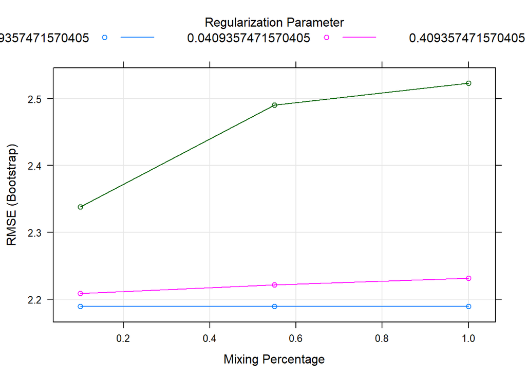

```r
plot(elnet1)
```

In all models, lambda is set to a very low value: Regularization does not offer much of a benefit.

## Regularized regressions with the glmnet package

Caret is great, but when I learned ridge and lasso regression, I had an easier time understanding using a “base” package, glmnet in this case, as it provides easier access to what’s going on under the hood.

#### Convert factor variable sex to dummy variables and standardize predictor variables

```r
dummy_train = dummyVars(" ~ .", data = abalone_train)
abalone_train2 = as_tibble(predict(dummy_train, newdata = abalone_train))
dummy_test = dummyVars(" ~ .", data = abalone_test)
abalone_test2 = as_tibble(predict(dummy_test, newdata = abalone_test))

x = preProcess(abalone_train2[,4:10], method = c("center", "scale"))
abalone_train2 = predict(x, abalone_train2)
abalone_test2 = predict(x, abalone_test2)
```

#### Ridge regression

```r
set.seed(123)
ridge3 = glmnet(as.matrix(abalone_train2[,1:10]), abalone_train2$rings, alpha = 0, nlambda = 100)
cv_ridge3 = cv.glmnet(as.matrix(abalone_train2[,1:10]), abalone_train2$rings, alpha = 0, nfolds = 10)
rings_pred_ridge3 <- predict(ridge3, s = cv_ridge3$lambda.min, newx = as.matrix(abalone_test2[,1:10]))
RMSE_ridge3 = sqrt(mean((rings_pred_ridge3 - abalone_test2$rings)^2))
cv_ridge3$lambda.min
```

```
## [1] 0.2246347
```

```r
RMSE_ridge3
```

```
## [1] 2.358289
```

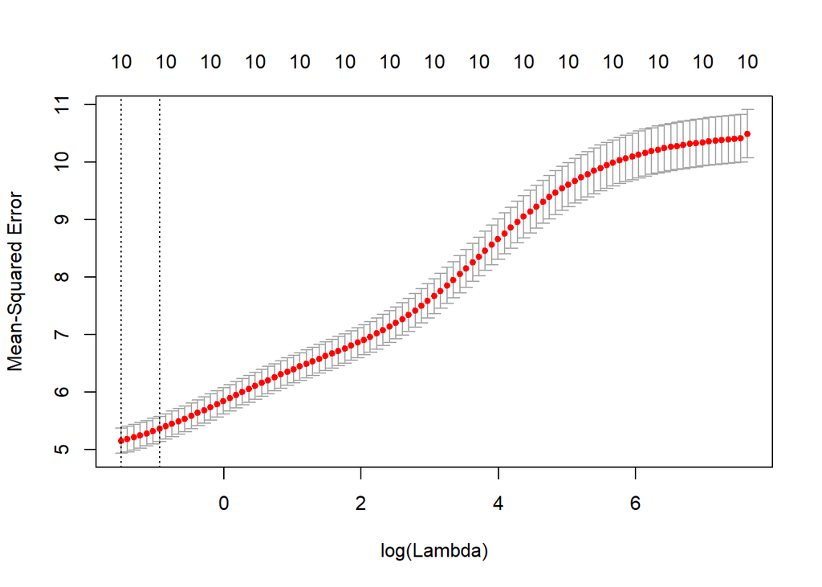

```r
plot(cv_ridge3)
```

#### Regression with lasso

```r
set.seed(123)
lasso3 = glmnet(as.matrix(abalone_train2[,1:10]), abalone_train2$rings, alpha = 1, nlambda = 100)
cv_lasso3 = cv.glmnet(as.matrix(abalone_train2[,1:10]), abalone_train2$rings, alpha = 1, nfolds = 10)
rings_pred_lasso3 <- predict(lasso3, s = cv_lasso3$lambda.min, newx = as.matrix(abalone_test2[,1:10]))
RMSE_lasso3 = sqrt(mean((rings_pred_lasso3 - abalone_test2$rings)^2))
coef(cv_lasso3, s = cv_lasso3$lambda.min)
```

```
## 11 x 1 sparse Matrix of class "dgCMatrix"
##                           1
## (Intercept)    10.150343155
## sex.F           .
## sex.I          -0.743174718
## sex.M           0.006831183
## length          .
## diameter        0.767193541
## height          0.890062824
## weight_whole    4.305026096
## weight_shucked -4.255300433
## weight_viscera -1.276301653
## weight_shell    1.172283398
```

```r
cv_lasso3$lambda.min
```

```
## [1] 0.00209495
```

```r
RMSE_lasso3
```

```
## [1] 2.291359
```

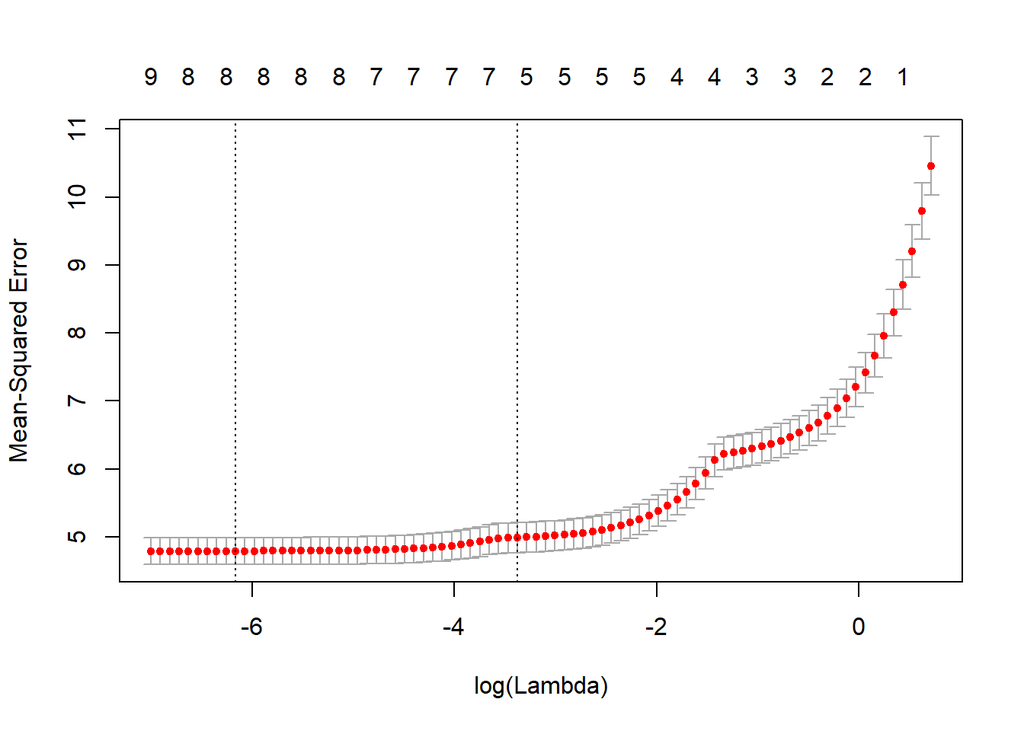

```r
plot(cv_lasso3)
```

#### Testing higher lambdas

```r
set.seed(123)
coef(glmnet(as.matrix(abalone_train2[,1:10]), abalone_train2$rings, alpha = 1, lambda = 0.1))
```

```
## 11 x 1 sparse Matrix of class "dgCMatrix"
##                        s0
## (Intercept)    10.1178860
## sex.F           .
## sex.I          -0.6343797
## sex.M           .
## length          .
## diameter        0.2317476
## height          0.8163317
## weight_whole    .
## weight_shucked -1.4557595
## weight_viscera  .
## weight_shell    2.1372287
```

```r
coef(glmnet(as.matrix(abalone_train2[,1:10]), abalone_train2$rings, alpha = 1, lambda = 0.5))
```

```
## 11 x 1 sparse Matrix of class "dgCMatrix"
##                         s0
## (Intercept)     9.92258806
## sex.F           .
## sex.I          -0.02717359
## sex.M           .
## length          .
## diameter        .
## height          0.42713600
## weight_whole    .
## weight_shucked  .
## weight_viscera  .
## weight_shell    1.16449613
```

```r
coef(glmnet(as.matrix(abalone_train2[,1:10]), abalone_train2$rings, alpha = 1, lambda = 1.0))
```

```
## 11 x 1 sparse Matrix of class "dgCMatrix"
##                       s0
## (Intercept)    9.9138481
## sex.F          .
## sex.I          .
## sex.M          .
## length         .
## diameter       .
## height         0.1650575
## weight_whole   .
## weight_shucked .
## weight_viscera .
## weight_shell   0.9018343
```

```r
coef(glmnet(as.matrix(abalone_train2[,1:10]), abalone_train2$rings, alpha = 1, lambda = 2.0))
```

```
## 11 x 1 sparse Matrix of class "dgCMatrix"
##                        s0
## (Intercept)    9.91384812
## sex.F          .
## sex.I          .
## sex.M          .
## length         .
## diameter       .
## height         .
## weight_whole   .
## weight_shucked .
## weight_viscera .
## weight_shell   0.04679482
```

As expected, increasing lambda decreases the number of variables included in the model.

## Stepwise model selection - with caret (leaps implementation)

#### Stepwise selection

```r
step1 = train(rings ~ ., data = abalone_train, method = "leapSeq")
step1
```

```
## Linear Regression with Stepwise Selection
##
## 3134 samples
##    8 predictor
##
## No pre-processing
## Resampling: Bootstrapped (25 reps)
## Summary of sample sizes: 3134, 3134, 3134, 3134, 3134, 3134, ...
## Resampling results across tuning parameters:
##
##   nvmax  RMSE      Rsquared   MAE
##   2      2.352882  0.4786173  1.710651
##   3      2.283697  0.5080674  1.656274
##   4      2.401191  0.4530075  1.734090
##
## RMSE was used to select the optimal model using the smallest value.
## The final value used for the model was nvmax = 3.
```

```r
summary(step1)
```

```
## Subset selection object
## 9 Variables  (and intercept)
##                Forced in Forced out
## sexI               FALSE      FALSE
## sexM               FALSE      FALSE
## length             FALSE      FALSE
## diameter           FALSE      FALSE
## height             FALSE      FALSE
## weight_whole       FALSE      FALSE
## weight_shucked     FALSE      FALSE
## weight_viscera     FALSE      FALSE
## weight_shell       FALSE      FALSE
## 1 subsets of each size up to 3
## Selection Algorithm: 'sequential replacement'
##          sexI sexM length diameter height weight_whole weight_shucked
## 1  ( 1 ) " "  " "  " "    " "      " "    " "          " "
## 2  ( 1 ) " "  " "  " "    " "      " "    " "          "*"
## 3  ( 1 ) " "  " "  " "    " "      "*"    " "          "*"
##          weight_viscera weight_shell
## 1  ( 1 ) " "            "*"
## 2  ( 1 ) " "            "*"
## 3  ( 1 ) " "            "*"
```

```r
rings_pred_step1 = predict(step1, newdata = abalone_test)
sqrt(mean((rings_pred_step1 - abalone_test$rings)^2))
```

```
## [1] 2.488449
```

With stepwise selection and default settings, caret chooses a model with only 3 predictors (height, shucked weight, and shell weight) as minimizing the root mean squared error by bootstrapping. In this sparser model, the RMSE on the test set is only slightly higher than in the full linear model.

Showing which predictors get selected for each number of predictors included:

```r
step3 = train(rings ~ ., data = abalone_train, method = "leapSeq",
            tuneGrid = expand.grid(nvmax = 9))
summary(step3)
```

```
## Subset selection object
## 9 Variables  (and intercept)
##                Forced in Forced out
## sexI               FALSE      FALSE
## sexM               FALSE      FALSE
## length             FALSE      FALSE
## diameter           FALSE      FALSE
## height             FALSE      FALSE
## weight_whole       FALSE      FALSE
## weight_shucked     FALSE      FALSE
## weight_viscera     FALSE      FALSE
## weight_shell       FALSE      FALSE
## 1 subsets of each size up to 9
## Selection Algorithm: 'sequential replacement'
##          sexI sexM length diameter height weight_whole weight_shucked
## 1  ( 1 ) " "  " "  " "    " "      " "    " "          " "
## 2  ( 1 ) " "  " "  " "    " "      " "    " "          "*"
## 3  ( 1 ) " "  " "  " "    " "      "*"    " "          "*"
## 4  ( 1 ) " "  " "  " "    " "      "*"    "*"          "*"
## 5  ( 1 ) " "  " "  " "    "*"      "*"    "*"          "*"
## 6  ( 1 ) "*"  " "  " "    "*"      "*"    "*"          "*"
## 7  ( 1 ) "*"  "*"  "*"    "*"      "*"    "*"          "*"
## 8  ( 1 ) "*"  " "  "*"    "*"      "*"    "*"          "*"
## 9  ( 1 ) "*"  "*"  "*"    "*"      "*"    "*"          "*"
##          weight_viscera weight_shell
## 1  ( 1 ) " "            "*"
## 2  ( 1 ) " "            "*"
## 3  ( 1 ) " "            "*"
## 4  ( 1 ) "*"            " "
## 5  ( 1 ) "*"            " "
## 6  ( 1 ) "*"            " "
## 7  ( 1 ) " "            " "
## 8  ( 1 ) "*"            "*"
## 9  ( 1 ) "*"            "*"
```

#### Backward selection

```r
back1 = train(rings ~ ., data = abalone_train, method = "leapBackward")
back1
```

```
## Linear Regression with Backwards Selection
##
## 3134 samples
##    8 predictor
##
## No pre-processing
## Resampling: Bootstrapped (25 reps)
## Summary of sample sizes: 3134, 3134, 3134, 3134, 3134, 3134, ...
## Resampling results across tuning parameters:
##
##   nvmax  RMSE      Rsquared   MAE
##   2      2.334053  0.4744143  1.707579
##   3      2.259537  0.5075098  1.648694
##   4      2.232635  0.5193156  1.622254
##
## RMSE was used to select the optimal model using the smallest value.
## The final value used for the model was nvmax = 4.
```

```r
summary(back1)
```

```
## Subset selection object
## 9 Variables  (and intercept)
##                Forced in Forced out
## sexI               FALSE      FALSE
## sexM               FALSE      FALSE
## length             FALSE      FALSE
## diameter           FALSE      FALSE
## height             FALSE      FALSE
## weight_whole       FALSE      FALSE
## weight_shucked     FALSE      FALSE
## weight_viscera     FALSE      FALSE
## weight_shell       FALSE      FALSE
## 1 subsets of each size up to 4
## Selection Algorithm: backward
##          sexI sexM length diameter height weight_whole weight_shucked
## 1  ( 1 ) " "  " "  " "    " "      " "    "*"          " "
## 2  ( 1 ) " "  " "  " "    " "      " "    "*"          "*"
## 3  ( 1 ) " "  " "  " "    " "      "*"    "*"          "*"
## 4  ( 1 ) " "  " "  " "    " "      "*"    "*"          "*"
##          weight_viscera weight_shell
## 1  ( 1 ) " "            " "
## 2  ( 1 ) " "            " "
## 3  ( 1 ) " "            " "
## 4  ( 1 ) "*"            " "
```

```r
rings_pred_back1 = predict(back1, newdata = abalone_test)
sqrt(mean((rings_pred_back1 - abalone_test$rings)^2))
```

```
## [1] 2.519021
```

#### Forward selection

```r
for1 = train(rings ~ ., data = abalone_train, method = "leapForward")
for1
```

```
## Linear Regression with Forward Selection
##
## 3134 samples
##    8 predictor
##
## No pre-processing
## Resampling: Bootstrapped (25 reps)
## Summary of sample sizes: 3134, 3134, 3134, 3134, 3134, 3134, ...
## Resampling results across tuning parameters:
##
##   nvmax  RMSE      Rsquared   MAE
##   2      2.354285  0.4749272  1.703500
##   3      2.287773  0.5037624  1.651706
##   4      2.265364  0.5133802  1.640928
##
## RMSE was used to select the optimal model using the smallest value.
## The final value used for the model was nvmax = 4.
```

```r
summary(for1)
```

```
## Subset selection object
## 9 Variables  (and intercept)
##                Forced in Forced out
## sexI               FALSE      FALSE
## sexM               FALSE      FALSE
## length             FALSE      FALSE
## diameter           FALSE      FALSE
## height             FALSE      FALSE
## weight_whole       FALSE      FALSE
## weight_shucked     FALSE      FALSE
## weight_viscera     FALSE      FALSE
## weight_shell       FALSE      FALSE
## 1 subsets of each size up to 4
## Selection Algorithm: forward
##          sexI sexM length diameter height weight_whole weight_shucked
## 1  ( 1 ) " "  " "  " "    " "      " "    " "          " "
## 2  ( 1 ) " "  " "  " "    " "      " "    " "          "*"
## 3  ( 1 ) " "  " "  " "    " "      "*"    " "          "*"
## 4  ( 1 ) " "  " "  " "    " "      "*"    "*"          "*"
##          weight_viscera weight_shell
## 1  ( 1 ) " "            "*"
## 2  ( 1 ) " "            "*"
## 3  ( 1 ) " "            "*"
## 4  ( 1 ) " "            "*"
```

```r
rings_pred_for1 = predict(for1, newdata = abalone_test)
sqrt(mean((rings_pred_for1 - abalone_test$rings)^2))
```

```
## [1] 2.41951
```

## Stepwise model selection - with leaps package, without caret

```r
step2 = regsubsets(rings ~ ., data = abalone_train, nvmax = 9)
summary(step2)
```

```
## Subset selection object
## Call: regsubsets.formula(rings ~ ., data = abalone_train, nvmax = 9)
## 9 Variables  (and intercept)
##                Forced in Forced out
## sexI               FALSE      FALSE
## sexM               FALSE      FALSE
## length             FALSE      FALSE
## diameter           FALSE      FALSE
## height             FALSE      FALSE
## weight_whole       FALSE      FALSE
## weight_shucked     FALSE      FALSE
## weight_viscera     FALSE      FALSE
## weight_shell       FALSE      FALSE
## 1 subsets of each size up to 9
## Selection Algorithm: exhaustive
##          sexI sexM length diameter height weight_whole weight_shucked
## 1  ( 1 ) " "  " "  " "    " "      " "    " "          " "
## 2  ( 1 ) " "  " "  " "    " "      " "    " "          "*"
## 3  ( 1 ) " "  " "  " "    " "      "*"    " "          "*"
## 4  ( 1 ) " "  " "  " "    " "      "*"    "*"          "*"
## 5  ( 1 ) " "  " "  " "    "*"      "*"    "*"          "*"
## 6  ( 1 ) "*"  " "  " "    "*"      "*"    "*"          "*"
## 7  ( 1 ) "*"  " "  " "    "*"      "*"    "*"          "*"
## 8  ( 1 ) "*"  " "  "*"    "*"      "*"    "*"          "*"
## 9  ( 1 ) "*"  "*"  "*"    "*"      "*"    "*"          "*"
##          weight_viscera weight_shell
## 1  ( 1 ) " "            "*"
## 2  ( 1 ) " "            "*"
## 3  ( 1 ) " "            "*"
## 4  ( 1 ) "*"            " "
## 5  ( 1 ) "*"            " "
## 6  ( 1 ) "*"            " "
## 7  ( 1 ) "*"            "*"
## 8  ( 1 ) "*"            "*"
## 9  ( 1 ) "*"            "*"
```

```r
names(summary(step2))
```

```
## [1] "which"  "rsq"    "rss"    "adjr2"  "cp"     "bic"    "outmat" "obj"
```

```r
summary(step2)$rss
```

```
## [1] 19717.35 17091.58 16026.76 15618.06 15284.19 15040.05 14890.29 14889.69
## [9] 14889.63
```

```r
summary(step2)$rsq
```

```
## [1] 0.3997166 0.4796566 0.5120745 0.5245171 0.5346817 0.5421145 0.5466737
## [8] 0.5466919 0.5466939
```

```r
summary(step2)$adjr2
```

```
## [1] 0.3995249 0.4793242 0.5116069 0.5239092 0.5339379 0.5412359 0.5456586
## [8] 0.5455315 0.5453879
```

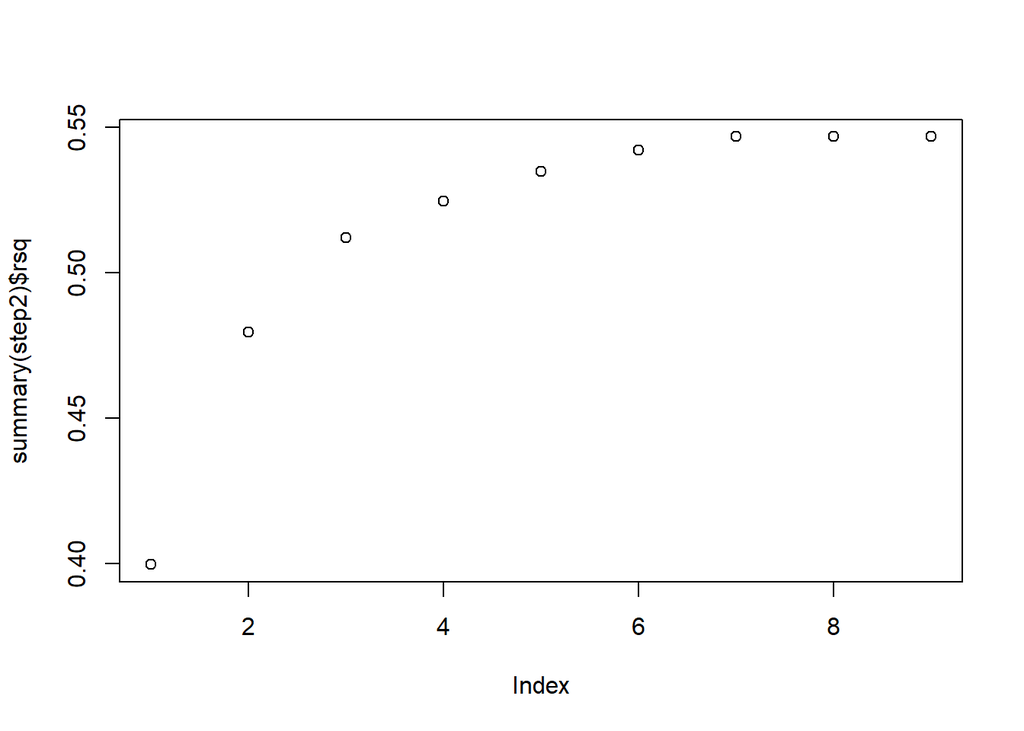

```r
plot(summary(step2)$rsq)
```

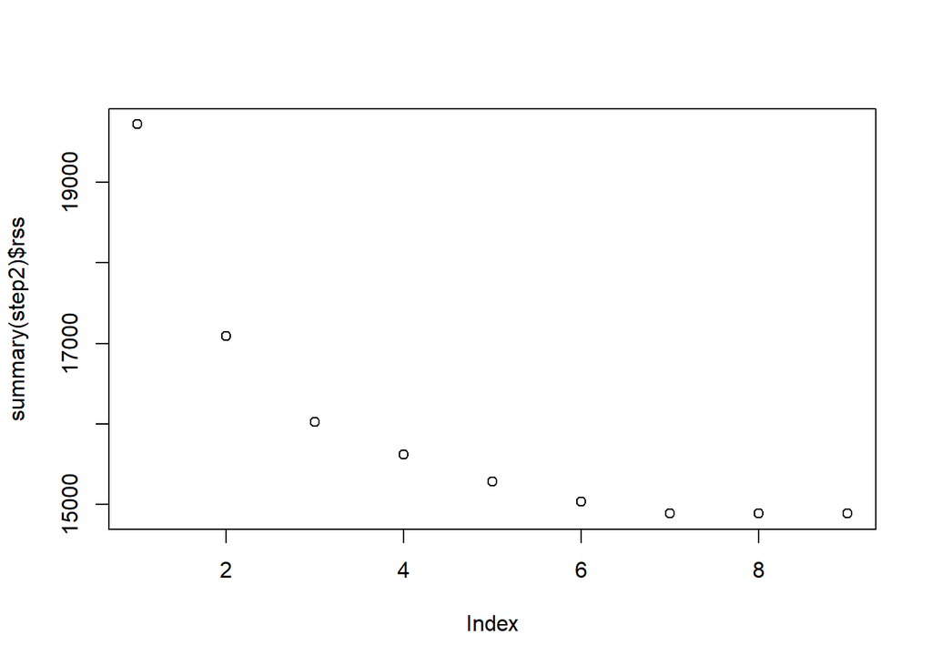

```r
plot(summary(step2)$rss)
```

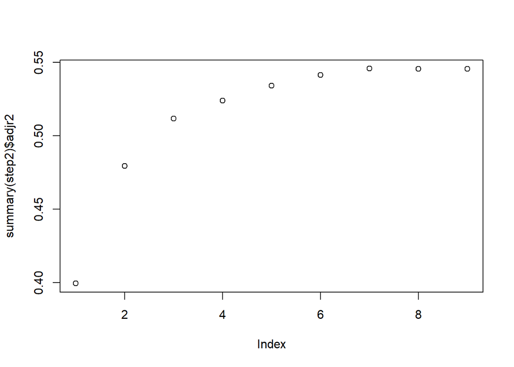

```r
plot(summary(step2)$adjr2)
```

#### Backward and forward selection

```r
back2 = regsubsets(rings ~ ., data = abalone_train, nvmax = 20, method = "backward")
for2 = regsubsets(rings ~ ., data = abalone_train, nvmax = 20, method = "forward")
summary(back2)
```

```
## Subset selection object
## Call: regsubsets.formula(rings ~ ., data = abalone_train, nvmax = 20,
##     method = "backward")
## 9 Variables  (and intercept)
##                Forced in Forced out
## sexI               FALSE      FALSE
## sexM               FALSE      FALSE
## length             FALSE      FALSE
## diameter           FALSE      FALSE
## height             FALSE      FALSE
## weight_whole       FALSE      FALSE
## weight_shucked     FALSE      FALSE
## weight_viscera     FALSE      FALSE
## weight_shell       FALSE      FALSE
## 1 subsets of each size up to 9
## Selection Algorithm: backward
##          sexI sexM length diameter height weight_whole weight_shucked
## 1  ( 1 ) " "  " "  " "    " "      " "    "*"          " "
## 2  ( 1 ) " "  " "  " "    " "      " "    "*"          "*"
## 3  ( 1 ) " "  " "  " "    " "      "*"    "*"          "*"
## 4  ( 1 ) " "  " "  " "    " "      "*"    "*"          "*"
## 5  ( 1 ) " "  " "  " "    "*"      "*"    "*"          "*"
## 6  ( 1 ) "*"  " "  " "    "*"      "*"    "*"          "*"
## 7  ( 1 ) "*"  " "  " "    "*"      "*"    "*"          "*"
## 8  ( 1 ) "*"  " "  "*"    "*"      "*"    "*"          "*"
## 9  ( 1 ) "*"  "*"  "*"    "*"      "*"    "*"          "*"
##          weight_viscera weight_shell
## 1  ( 1 ) " "            " "
## 2  ( 1 ) " "            " "
## 3  ( 1 ) " "            " "
## 4  ( 1 ) "*"            " "
## 5  ( 1 ) "*"            " "
## 6  ( 1 ) "*"            " "
## 7  ( 1 ) "*"            "*"
## 8  ( 1 ) "*"            "*"
## 9  ( 1 ) "*"            "*"
```

```r
summary(for2)
```

```
## Subset selection object
## Call: regsubsets.formula(rings ~ ., data = abalone_train, nvmax = 20,
##     method = "forward")
## 9 Variables  (and intercept)
##                Forced in Forced out
## sexI               FALSE      FALSE
## sexM               FALSE      FALSE
## length             FALSE      FALSE
## diameter           FALSE      FALSE
## height             FALSE      FALSE
## weight_whole       FALSE      FALSE
## weight_shucked     FALSE      FALSE
## weight_viscera     FALSE      FALSE
## weight_shell       FALSE      FALSE
## 1 subsets of each size up to 9
## Selection Algorithm: forward
##          sexI sexM length diameter height weight_whole weight_shucked
## 1  ( 1 ) " "  " "  " "    " "      " "    " "          " "
## 2  ( 1 ) " "  " "  " "    " "      " "    " "          "*"
## 3  ( 1 ) " "  " "  " "    " "      "*"    " "          "*"
## 4  ( 1 ) " "  " "  " "    " "      "*"    "*"          "*"
## 5  ( 1 ) "*"  " "  " "    " "      "*"    "*"          "*"
## 6  ( 1 ) "*"  " "  " "    " "      "*"    "*"          "*"
## 7  ( 1 ) "*"  " "  " "    "*"      "*"    "*"          "*"
## 8  ( 1 ) "*"  " "  "*"    "*"      "*"    "*"          "*"
## 9  ( 1 ) "*"  "*"  "*"    "*"      "*"    "*"          "*"
##          weight_viscera weight_shell
## 1  ( 1 ) " "            "*"
## 2  ( 1 ) " "            "*"
## 3  ( 1 ) " "            "*"
## 4  ( 1 ) " "            "*"
## 5  ( 1 ) " "            "*"
## 6  ( 1 ) "*"            "*"
## 7  ( 1 ) "*"            "*"
## 8  ( 1 ) "*"            "*"
## 9  ( 1 ) "*"            "*"
```

## Principal Component Analysis - with caret

#### Correlation table of all numeric predictors

```r
kable(cor(abalone_train[,2:8]), caption = "correlation table of all numeric predictors")
```

correlation table of all numeric predictors

|  | length | diameter | height | weight_whole | weight_shucked | weight_viscera | weight_shell |
| --- | --- | --- | --- | --- | --- | --- | --- |
| length | 1.0000000 | 0.9876898 | 0.8930925 | 0.9263648 | 0.8961603 | 0.9038949 | 0.9002521 |
| diameter | 0.9876898 | 1.0000000 | 0.8972942 | 0.9258713 | 0.8912030 | 0.9003254 | 0.9069831 |
| height | 0.8930925 | 0.8972942 | 1.0000000 | 0.8805931 | 0.8313893 | 0.8616470 | 0.8792097 |
| weight_whole | 0.9263648 | 0.9258713 | 0.8805931 | 1.0000000 | 0.9696024 | 0.9683524 | 0.9546472 |
| weight_shucked | 0.8961603 | 0.8912030 | 0.8313893 | 0.9696024 | 1.0000000 | 0.9310904 | 0.8802089 |
| weight_viscera | 0.9038949 | 0.9003254 | 0.8616470 | 0.9683524 | 0.9310904 | 1.0000000 | 0.9104702 |
| weight_shell | 0.9002521 | 0.9069831 | 0.8792097 | 0.9546472 | 0.8802089 | 0.9104702 | 1.0000000 |

#### Prediction with PCA preprocessing

```r
pca_object = preProcess(abalone_train[, 2:8], method = "pca")
pca_object
```

```
## Created from 3134 samples and 7 variables
##
## Pre-processing:
##   - centered (7)
##   - ignored (0)
##   - principal component signal extraction (7)
##   - scaled (7)
##
## PCA needed 2 components to capture 95 percent of the variance
```

```r
pca_train = predict(pca_object, abalone_train[, 2:8])
pca_train = cbind(pca_train, rings = abalone_train$rings)
pca1 = train(rings ~ PC1 + PC2, method = "glm", data = pca_train)
pca1
```

```
## Generalized Linear Model
##
## 3134 samples
##    2 predictor
##
## No pre-processing
## Resampling: Bootstrapped (25 reps)
## Summary of sample sizes: 3134, 3134, 3134, 3134, 3134, 3134, ...
## Resampling results:
##
##   RMSE      Rsquared   MAE
##   2.486244  0.4131284  1.801747
```

```r
pca_test = predict(pca_object, abalone_test[, 2:8])
pca_test = cbind(pca_test, rings = abalone_test$rings)
rings_pred_pca1 = predict(pca1, newdata = pca_test)
sqrt(mean((rings_pred_pca1 - abalone_test$rings)^2))
```

```
## [1] 2.746251
```

Caret’s PCA preprocessing function automatically calculates the number of prinicipal components needed to capture (by default) 95% of the variance of all variables that are passed to the function. In this example, this is 2 components. The RMSE of predicted vs actual rings in the test set is about 0.5 higher than of the models with all predictors

## Predicting the number of rings with a non-parametric model for comparison: KNN

```r
knn1 = train(rings ~ ., data = abalone_train, method = "knn")
knn1
```

```
## k-Nearest Neighbors
##
## 3134 samples
##    8 predictor
##
## No pre-processing
## Resampling: Bootstrapped (25 reps)
## Summary of sample sizes: 3134, 3134, 3134, 3134, 3134, 3134, ...
## Resampling results across tuning parameters:
##
##   k  RMSE      Rsquared   MAE
##   5  2.405295  0.4677237  1.679028
##   7  2.340845  0.4892546  1.634590
##   9  2.306471  0.5017516  1.607334
##
## RMSE was used to select the optimal model using the smallest value.
## The final value used for the model was k = 9.
```

```r
rings_pred_knn1 = predict(knn1, newdata = abalone_test)
sqrt(mean((rings_pred_knn1 - abalone_test$rings)^2))
```

```
## [1] 2.220072
```

```r
knn2 = train(rings ~ ., data = abalone_train, method = "knn", preProcess = c("center","scale"))
rings_pred_knn2 = predict(knn2, newdata = abalone_test)
sqrt(mean((rings_pred_knn2 - abalone_test$rings)^2))
```

```
## [1] 2.312286
```

Letting caret select the optimal number of nearest neighbors, prediction accuracy on the test set is about as high as in the parametric model.